# Analysing data

- Currently 33 zettabytes
  - 2025: 173 zettabytes [IDC](https://www.emc.com/collateral/analyst-reports/idc-the-digital-universe-in-2020.pdf)
  - [173'000'000'000'000'000'000'000](https://en.wikipedia.org/wiki/Zettabyte)
- Your future company will bathe in data about everything
- You need to learn how to use data and extract valuable information from it

## Analysing data with models

> All models are wrong, but some are useful

Source: [Several](https://en.wikipedia.org/wiki/All_models_are_wrong)

## Pandas

[Pandas](https://pandas.pydata.org/) is a library for Python that helps you do this.

Install it now by typing:

```
$ pip install pandas
```

## Pandas dataframes

Pandas works a bit like the `openpyxl` module: you get a 'sheet' of data and read it in columns.

Let's do that together now.

```python
import pandas as pd
import matplotlib.pyplot as plt
```

But we need a data source!

https://www.dr.dk/nyheder/indland/aeldre-bliver-rigere-unge-fattigere

https://www.dst.dk/da/Statistik/emner/arbejde-indkomst-og-formue/indkomster

https://www.dst.dk/da/Statistik/nyt/NytHtml?cid=29483

```python
df = pd.read_csv('data/2019721183544253670048AINDK267296307071.csv', encoding='cp1252', header=None)
```

df = pd.read_csv('data/2019721183544253670048AINDK267296307071.csv', header=None, encoding='cp1252')

```python
print(df)
```

```
      0                                        1            2   \
0   Alle  Gennemsnit for personer i gruppen (kr.)  Hele landet
1   Alle  Gennemsnit for personer i gruppen (kr.)  Hele landet
2   Alle  Gennemsnit for personer i gruppen (kr.)  Hele landet
3   Alle  Gennemsnit for personer i gruppen (kr.)  Hele landet
4   Alle  Gennemsnit for personer i gruppen (kr.)  Hele landet
5   Alle  Gennemsnit for personer i gruppen (kr.)  Hele landet
6   Alle  Gennemsnit for personer i gruppen (kr.)  Hele landet
7   Alle  Gennemsnit for personer i gruppen (kr.)  Hele landet
8   Alle  Gennemsnit for personer i gruppen (kr.)  Hele landet
9   Alle  Gennemsnit for personer i gruppen (kr.)  Hele landet
10  Alle  Gennemsnit for personer i gruppen (kr.)  Hele landet
11  Alle  Gennemsnit for personer i gruppen (kr.)  Hele landet
12  Alle  Gennemsnit for personer i gruppen (kr.)  Hele landet
13  Alle  Gennemsnit for personer i gruppen (kr.)  Hele landet
```

[output cut: 116 more lines]

print(df.head())

```python
df.head()
```

[output not shown]

```python
df.columns = ['','', 'region', 'sex', 'age', '2018', '2017', '2016', '2015', '2014', '2013', '2012']
```

```python
df.head()
```

|  |  |  | region | sex | age | 2018 | 2017 | 2016 | 2015 | 2014 | 2013 | 2012 |
| --- | --- | --- | --- | --- | --- | --- | --- | --- | --- | --- | --- | --- |
| 0 | Alle | Gennemsnit for personer i gruppen (kr.) | Hele landet | Mænd og kvinder i alt | I alt | 284229 | 277182 | 271263 | 266011 | 261323 | 256720 | 253633 |
| 1 | Alle | Gennemsnit for personer i gruppen (kr.) | Hele landet | Mænd og kvinder i alt | 15-19 år | 32303 | 31214 | 30550 | 30663 | 30913 | 30968 | 30729 |
| 2 | Alle | Gennemsnit for personer i gruppen (kr.) | Hele landet | Mænd og kvinder i alt | 20-24 år | 148007 | 143404 | 140777 | 138216 | 136554 | 136120 | 136981 |
| 3 | Alle | Gennemsnit for personer i gruppen (kr.) | Hele landet | Mænd og kvinder i alt | 25-29 år | 241316 | 233509 | 227399 | 223795 | 221154 | 221144 | 221142 |
| 4 | Alle | Gennemsnit for personer i gruppen (kr.) | Hele landet | Mænd og kvinder i alt | 30-34 år | 314514 | 306880 | 301088 | 297700 | 295332 | 292969 | 292867 |

```python
df['age']
```

```
0          I alt
1       15-19 år
2       20-24 år
3       25-29 år
4       30-34 år
5       35-39 år
6       40-44 år
7       45-49 år
8       50-54 år
9       55-59 år
10      60-64 år
11      65-69 år
12      70-74 år
13    Over 74 år
14         I alt
```

[output cut: 28 more lines]

```python
both = pd.DataFrame()
```

```python
both['age'] = df['age'][1:14]
both
```

|  | age |
| --- | --- |
| 1 | 15-19 år |
| 2 | 20-24 år |
| 3 | 25-29 år |
| 4 | 30-34 år |
| 5 | 35-39 år |
| 6 | 40-44 år |
| 7 | 45-49 år |
| 8 | 50-54 år |
| 9 | 55-59 år |
| 10 | 60-64 år |
| 11 | 65-69 år |
| 12 | 70-74 år |
| 13 | Over 74 år |

```python
df['2018']
```

```
0     284229
1      32303
2     148007
3     241316
4     314514
5     356969
6     387646
7     402691
8     398236
9     373912
10    334379
11    255086
12    228863
13    208960
14    314847
```

[output cut: 28 more lines]

```python
# Crop columns to only contain 1 to 13
for i in range(2012, 2019):
    name = str(i)
    both[name] = df[name][1:14]
```

```python
for i in range(2012, 2019):
    name = str(i)
    both[name] = df[name][1:14]
```

```python
both
```

|  | age | 2012 | 2013 | 2014 | 2015 | 2016 | 2017 | 2018 |
| --- | --- | --- | --- | --- | --- | --- | --- | --- |
| 1 | 15-19 år | 30729 | 30968 | 30913 | 30663 | 30550 | 31214 | 32303 |
| 2 | 20-24 år | 136981 | 136120 | 136554 | 138216 | 140777 | 143404 | 148007 |
| 3 | 25-29 år | 221142 | 221144 | 221154 | 223795 | 227399 | 233509 | 241316 |
| 4 | 30-34 år | 292867 | 292969 | 295332 | 297700 | 301088 | 306880 | 314514 |
| 5 | 35-39 år | 329390 | 331987 | 336800 | 340677 | 344405 | 349822 | 356969 |
| 6 | 40-44 år | 348565 | 352791 | 360400 | 367124 | 372705 | 378667 | 387646 |
| 7 | 45-49 år | 354207 | 359934 | 367719 | 375173 | 384518 | 392978 | 402691 |
| 8 | 50-54 år | 341877 | 348173 | 356547 | 366963 | 377151 | 387921 | 398236 |
| 9 | 55-59 år | 327239 | 333227 | 341197 | 347395 | 355318 | 363464 | 373912 |
| 10 | 60-64 år | 280116 | 286658 | 295302 | 304038 | 313657 | 324254 | 334379 |
| 11 | 65-69 år | 216395 | 222163 | 228911 | 235244 | 242129 | 248967 | 255086 |
| 12 | 70-74 år | 190449 | 197081 | 203725 | 210224 | 217404 | 222601 | 228863 |
| 13 | Over 74 år | 178967 | 184403 | 188809 | 193130 | 198051 | 203070 | 208960 |

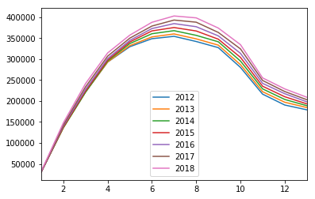

```python
both.plot()
```

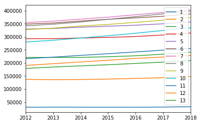

```python
both.T[1:].plot()
```

## Plotting with pandas

Pandas `DataFrame`s have a simple `.plot()` method, which plots **columns as y values** and **rows as x values**.

https://pandas.pydata.org/pandas-docs/stable/reference/api/pandas.DataFrame.plot.line.html#pandas.DataFrame.plot.line

You can also plot barcharts, histograms etc.

```python
both_index = pd.DataFrame()
```

```python
both_index['age'] = both['age']
```

```python
for i in range(2012, 2019):
    name = str(i)
    both_index[name] = df[name][1:14] - df['2012'][1:14]
both_index
```

|  | age | 2012 | 2013 | 2014 | 2015 | 2016 | 2017 | 2018 |
| --- | --- | --- | --- | --- | --- | --- | --- | --- |
| 1 | 15-19 år | 0 | 239 | 184 | -66 | -179 | 485 | 1574 |
| 2 | 20-24 år | 0 | -861 | -427 | 1235 | 3796 | 6423 | 11026 |
| 3 | 25-29 år | 0 | 2 | 12 | 2653 | 6257 | 12367 | 20174 |
| 4 | 30-34 år | 0 | 102 | 2465 | 4833 | 8221 | 14013 | 21647 |
| 5 | 35-39 år | 0 | 2597 | 7410 | 11287 | 15015 | 20432 | 27579 |
| 6 | 40-44 år | 0 | 4226 | 11835 | 18559 | 24140 | 30102 | 39081 |
| 7 | 45-49 år | 0 | 5727 | 13512 | 20966 | 30311 | 38771 | 48484 |
| 8 | 50-54 år | 0 | 6296 | 14670 | 25086 | 35274 | 46044 | 56359 |
| 9 | 55-59 år | 0 | 5988 | 13958 | 20156 | 28079 | 36225 | 46673 |
| 10 | 60-64 år | 0 | 6542 | 15186 | 23922 | 33541 | 44138 | 54263 |
| 11 | 65-69 år | 0 | 5768 | 12516 | 18849 | 25734 | 32572 | 38691 |
| 12 | 70-74 år | 0 | 6632 | 13276 | 19775 | 26955 | 32152 | 38414 |
| 13 | Over 74 år | 0 | 5436 | 9842 | 14163 | 19084 | 24103 | 29993 |

```
for i in range(2012, 2019):
    name = str(i)
    both_index[name] = df[name][1:14] - df['2012'][1:14]
```

```python
both_index
```

|  | age | 2012 | 2013 | 2014 | 2015 | 2016 | 2017 | 2018 |
| --- | --- | --- | --- | --- | --- | --- | --- | --- |
| 1 | 15-19 år | 0 | 239 | 184 | -66 | -179 | 485 | 1574 |
| 2 | 20-24 år | 0 | -861 | -427 | 1235 | 3796 | 6423 | 11026 |
| 3 | 25-29 år | 0 | 2 | 12 | 2653 | 6257 | 12367 | 20174 |
| 4 | 30-34 år | 0 | 102 | 2465 | 4833 | 8221 | 14013 | 21647 |
| 5 | 35-39 år | 0 | 2597 | 7410 | 11287 | 15015 | 20432 | 27579 |
| 6 | 40-44 år | 0 | 4226 | 11835 | 18559 | 24140 | 30102 | 39081 |
| 7 | 45-49 år | 0 | 5727 | 13512 | 20966 | 30311 | 38771 | 48484 |
| 8 | 50-54 år | 0 | 6296 | 14670 | 25086 | 35274 | 46044 | 56359 |
| 9 | 55-59 år | 0 | 5988 | 13958 | 20156 | 28079 | 36225 | 46673 |
| 10 | 60-64 år | 0 | 6542 | 15186 | 23922 | 33541 | 44138 | 54263 |
| 11 | 65-69 år | 0 | 5768 | 12516 | 18849 | 25734 | 32572 | 38691 |
| 12 | 70-74 år | 0 | 6632 | 13276 | 19775 | 26955 | 32152 | 38414 |
| 13 | Over 74 år | 0 | 5436 | 9842 | 14163 | 19084 | 24103 | 29993 |

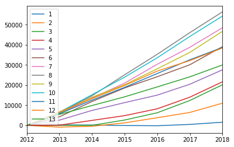

```python
both_index.T[1:].plot()
plt.show()
```

## Exercise!

Use the dataset available from GitHub: `session-10/data`

- Can you do the same thing for men and women exclusively?
  - Try to turn the problem into a function. The code will almost be the same, but what will change?
- Bonus question: Normalise to percentages
  - The numbers in the graph are pretty big, can you divide by the maximum number in all the columns?
    - This should give you values that are at maximum 1

## How green is Denmark?!

http://databank.worldbank.org/data/reports.aspx?source=&series=EG.ELC.RNEW.ZS

https://databank.worldbank.org/source/world-development-indicators

```python
wb = pd.read_csv('data/abcc94ae-70a2-4ca3-bfc8-5d6ddc6803d8_Data.csv')
```

```
wb = pd.read_csv('data/abcc94ae-70a2-4ca3-bfc8-5d6ddc6803d8_Data.csv')
```

wb

### Pandas `.loc()`

Slices the dataset using both row and column indices:

`df.loc[rows, columns]`

For example:

- `df.loc[:, :]`
- `df.loc[0, 1960:2018]`

Great resource: https://medium.com/dunder-data/selecting-subsets-of-data-in-pandas-6fcd0170be9c

```python
wb.loc[:, '1960 [YR1960]':'2018 [YR2018]']
```

|  | 1960 [YR1960] | 1961 [YR1961] | 1962 [YR1962] | 1963 [YR1963] | 1964 [YR1964] | 1965 [YR1965] | 1966 [YR1966] | 1967 [YR1967] | 1968 [YR1968] | 1969 [YR1969] | ... | 2009 [YR2009] | 2010 [YR2010] | 2011 [YR2011] | 2012 [YR2012] | 2013 [YR2013] | 2014 [YR2014] | 2015 [YR2015] | 2016 [YR2016] | 2017 [YR2017] | 2018 [YR2018] |
| --- | --- | --- | --- | --- | --- | --- | --- | --- | --- | --- | --- | --- | --- | --- | --- | --- | --- | --- | --- | --- | --- |
| 0 | .. | .. | .. | .. | .. | .. | .. | .. | .. | .. | ... | 19.342764 | 21.354836 | 23.898967 | 27.281957 | 27.342839 | 30.271631 | 33.170277 | .. | .. | .. |
| 1 | .. | .. | .. | .. | .. | .. | .. | .. | .. | .. | ... | 7.354405 | 7.505172 | 8.164452 | 8.481450 | 8.713262 | 8.754309 | 8.716936 | .. | .. | .. |
| 2 | .. | .. | .. | .. | .. | .. | .. | .. | .. | .. | ... | 3.383032 | 3.638918 | 4.401119 | 4.751258 | 6.015781 | 7.395220 | 8.711686 | .. | .. | .. |
| 3 | .. | .. | .. | .. | .. | .. | .. | .. | .. | .. | ... | 9.630062 | 10.293520 | 11.394356 | 12.015136 | 12.089079 | 13.378878 | 14.206253 | .. | .. | .. |
| 4 | .. | .. | .. | .. | .. | .. | .. | .. | .. | .. | ... | 56.770925 | 56.424556 | 56.529329 | 58.275850 | 57.725950 | 57.196402 | 57.772002 | .. | .. | .. |
| 5 | .. | .. | .. | .. | .. | .. | .. | .. | .. | .. | ... | 47.077364 | 45.977806 | 46.487030 | 49.948550 | 48.825222 | 49.693415 | 53.247770 | .. | .. | .. |
| 6 | .. | .. | .. | .. | .. | .. | .. | .. | .. | .. | ... | 15.570293 | 17.079802 | 16.978595 | 16.632885 | 16.097394 | 16.588162 | 17.150141 | .. | .. | .. |
| 7 | .. | .. | .. | .. | .. | .. | .. | .. | .. | .. | ... | 7.112827 | 8.109027 | 8.256181 | 8.247109 | 9.088482 | 9.278198 | 9.180503 | .. | .. | .. |
| 8 | .. | .. | .. | .. | .. | .. | .. | .. | .. | .. | ... | 40.770828 | 39.481509 | 38.931740 | 38.390890 | 37.849841 | 36.651838 | 36.021223 | .. | .. | .. |
| 9 | .. | .. | .. | .. | .. | .. | .. | .. | .. | .. | ... | 13.911962 | 12.884310 | 11.695797 | 11.968567 | 11.838167 | 12.223823 | 12.413353 | .. | .. | .. |
| 10 | .. | .. | .. | .. | .. | .. | .. | .. | .. | .. | ... | 49.113723 | 47.006662 | 45.468551 | 43.620795 | 42.447843 | 41.841879 | 43.790389 | .. | .. | .. |
| 11 | NaN | NaN | NaN | NaN | NaN | NaN | NaN | NaN | NaN | NaN | ... | NaN | NaN | NaN | NaN | NaN | NaN | NaN | NaN | NaN | NaN |
| 12 | NaN | NaN | NaN | NaN | NaN | NaN | NaN | NaN | NaN | NaN | ... | NaN | NaN | NaN | NaN | NaN | NaN | NaN | NaN | NaN | NaN |
| 13 | NaN | NaN | NaN | NaN | NaN | NaN | NaN | NaN | NaN | NaN | ... | NaN | NaN | NaN | NaN | NaN | NaN | NaN | NaN | NaN | NaN |
| 14 | NaN | NaN | NaN | NaN | NaN | NaN | NaN | NaN | NaN | NaN | ... | NaN | NaN | NaN | NaN | NaN | NaN | NaN | NaN | NaN | NaN |
| 15 | NaN | NaN | NaN | NaN | NaN | NaN | NaN | NaN | NaN | NaN | ... | NaN | NaN | NaN | NaN | NaN | NaN | NaN | NaN | NaN | NaN |

16 rows × 59 columns

```python
wb_data = wb.loc[:10, '1990 [YR1990]':'2015 [YR2015]'].T
```

```python
 wb_data
```

```
wb_data = wb.loc[:10, '1990 [YR1990]':'2015 [YR2015]'].T
```

```python
wb_data.columns = wb['Country Name'][:11]
wb_data
```

| Country Name | Denmark | United States | United Kingdom | Germany | Norway | Sweden | South Africa | Australia | India | China | Brazil |
| --- | --- | --- | --- | --- | --- | --- | --- | --- | --- | --- | --- |
| 1990 [YR1990] | 7.041560 | 4.175462 | 0.651134 | 2.098034 | 59.173746 | 34.061992 | 16.627822 | 8.009577 | 58.652858 | 34.083614 | 49.864675 |
| 1991 [YR1991] | 7.070899 | 4.507920 | 0.608264 | 1.988633 | 60.784880 | 32.458792 | 17.466119 | 8.245472 | 57.604793 | 33.258474 | 48.938168 |
| 1992 [YR1992] | 7.747445 | 4.763083 | 0.840738 | 2.062622 | 61.378964 | 33.232161 | 18.363217 | 7.516471 | 57.230567 | 32.931278 | 48.701183 |
| 1993 [YR1993] | 7.701497 | 4.281528 | 0.775205 | 2.110931 | 61.097328 | 34.385152 | 18.585950 | 8.616994 | 56.983363 | 31.677792 | 48.199088 |
| 1994 [YR1994] | 7.330399 | 4.088641 | 1.021428 | 2.266202 | 60.398946 | 31.354424 | 18.562882 | 8.259947 | 55.557187 | 31.249484 | 48.350009 |
| 1995 [YR1995] | 7.512178 | 4.726554 | 1.060229 | 2.319749 | 60.047125 | 33.914181 | 18.113080 | 8.217806 | 54.484117 | 29.472111 | 46.134357 |
| 1996 [YR1996] | 7.261181 | 4.763930 | 0.943587 | 2.252174 | 57.850555 | 31.356097 | 17.437771 | 8.865971 | 53.767410 | 30.537175 | 44.532882 |
| 1997 [YR1997] | 8.102730 | 4.514260 | 1.028480 | 2.824422 | 58.838879 | 35.620611 | 17.107191 | 9.080243 | 52.488073 | 30.183482 | 43.725108 |
| 1998 [YR1998] | 8.517843 | 4.534297 | 1.029704 | 3.045119 | 59.516916 | 35.657903 | 17.272490 | 8.595073 | 52.712256 | 29.739901 | 43.861577 |
| 1999 [YR1999] | 9.066353 | 5.709727 | 0.948918 | 3.263712 | 59.414947 | 34.792250 | 18.221320 | 8.507274 | 51.717294 | 30.506049 | 44.097276 |
| 2000 [YR2000] | 10.737201 | 5.429624 | 0.961902 | 3.700438 | 60.188131 | 40.008259 | 18.508080 | 8.423341 | 51.579348 | 29.730715 | 42.798774 |
| 2001 [YR2001] | 11.123600 | 4.678571 | 0.852867 | 3.899673 | 59.606409 | 37.661576 | 19.121442 | 8.370281 | 51.787219 | 28.455815 | 41.477879 |
| 2002 [YR2002] | 11.865879 | 4.840779 | 0.970071 | 4.412637 | 59.493113 | 36.148761 | 18.324104 | 8.738721 | 50.569443 | 27.098202 | 43.024562 |
| 2003 [YR2003] | 12.720307 | 5.326282 | 0.934980 | 5.058467 | 56.256869 | 34.910426 | 17.506563 | 7.151066 | 50.842799 | 23.946580 | 45.308661 |
| 2004 [YR2004] | 14.449070 | 5.477657 | 1.137258 | 5.825244 | 56.871607 | 35.823312 | 16.760797 | 6.680426 | 49.724025 | 20.249479 | 45.389961 |
| 2005 [YR2005] | 16.126398 | 5.841091 | 1.352280 | 6.764551 | 58.591810 | 39.991895 | 16.245342 | 6.711975 | 48.575309 | 18.203819 | 46.347941 |
| 2006 [YR2006] | 15.267124 | 6.396514 | 1.553920 | 7.753225 | 57.059690 | 41.126588 | 16.370397 | 6.853267 | 47.443722 | 17.094610 | 46.905060 |
| 2007 [YR2007] | 17.700928 | 6.304128 | 1.839651 | 9.406588 | 57.390066 | 42.924655 | 15.811629 | 6.951586 | 45.867804 | 15.349371 | 47.417625 |
| 2008 [YR2008] | 18.549255 | 6.845541 | 2.782792 | 8.592248 | 58.493733 | 44.865588 | 15.986590 | 6.789569 | 43.632883 | 14.601997 | 47.263307 |
| 2009 [YR2009] | 19.342764 | 7.354405 | 3.383032 | 9.630062 | 56.770925 | 47.077364 | 15.570293 | 7.112827 | 40.770828 | 13.911962 | 49.113723 |
| 2010 [YR2010] | 21.354836 | 7.505172 | 3.638918 | 10.293520 | 56.424556 | 45.977806 | 17.079802 | 8.109027 | 39.481509 | 12.884310 | 47.006662 |
| 2011 [YR2011] | 23.898967 | 8.164452 | 4.401119 | 11.394356 | 56.529329 | 46.487030 | 16.978595 | 8.256181 | 38.931740 | 11.695797 | 45.468551 |
| 2012 [YR2012] | 27.281957 | 8.481450 | 4.751258 | 12.015136 | 58.275850 | 49.948550 | 16.632885 | 8.247109 | 38.390890 | 11.968567 | 43.620795 |
| 2013 [YR2013] | 27.342839 | 8.713262 | 6.015781 | 12.089079 | 57.725950 | 48.825222 | 16.097394 | 9.088482 | 37.849841 | 11.838167 | 42.447843 |
| 2014 [YR2014] | 30.271631 | 8.754309 | 7.395220 | 13.378878 | 57.196402 | 49.693415 | 16.588162 | 9.278198 | 36.651838 | 12.223823 | 41.841879 |
| 2015 [YR2015] | 33.170277 | 8.716936 | 8.711686 | 14.206253 | 57.772002 | 53.247770 | 17.150141 | 9.180503 | 36.021223 | 12.413353 | 43.790389 |

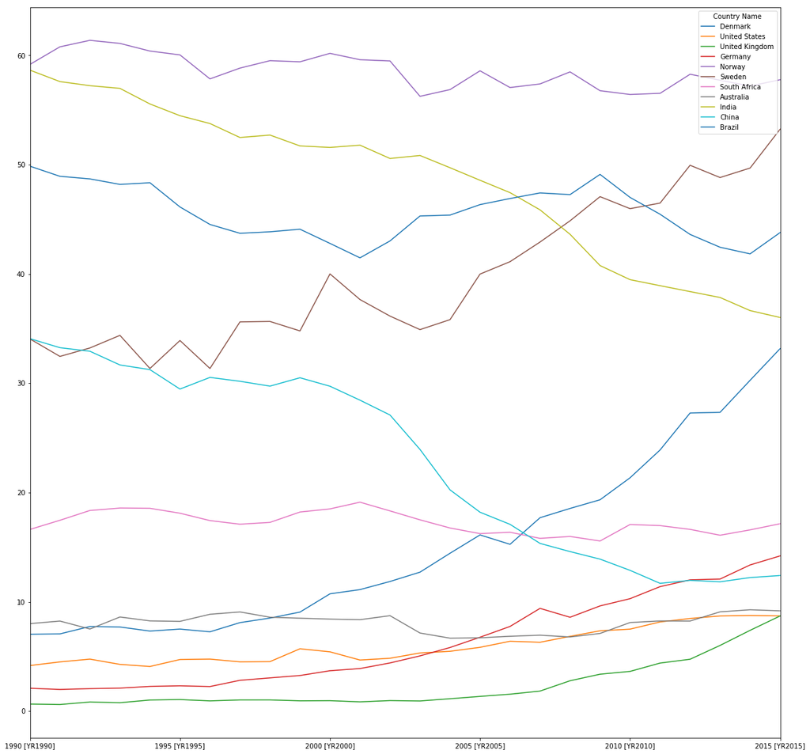

```python
wb_data.plot(figsize=(20, 20))
```

```
wb_data.plot(figsize=(20, 20))
```

## Exercise

We only care about our northern bretheren of course. Can you filter our all the other countries? Perhaps using `.loc`?

Use the dataset available from GitHub: `session-10/data`

```
import pandas as pd
import matplotlib.pyplot as plt

wb = pd.read_csv('abcc94ae-70a2-4ca3-bfc8-5d6ddc6803d8_Data.csv')
wb_data = wb.loc[:10, '1990 [YR1990]':'2015 [YR2015]'].T
wb_data.columns = wb['Country Name'][:11]
wb_data.plot()
plt.show()
```

## How many from the Ivory Coast lives in Copenhagen?

```python
cph = pd.read_csv('data/befkbhalderstatkode_small.csv')
cph.head()
```

|  | AAR | BYDEL | ALDER | STATKODE | PERSONER |
| --- | --- | --- | --- | --- | --- |
| 0 | 2015 | 1 | 0 | 5100 | 614 |
| 1 | 2015 | 1 | 0 | 5104 | 2 |
| 2 | 2015 | 1 | 0 | 5106 | 1 |
| 3 | 2015 | 1 | 0 | 5110 | 1 |
| 4 | 2015 | 1 | 0 | 5120 | 4 |

```python
KBH_NEIGHBORHOODS = {
    '1': 'Indre By',
    '2': 'Østerbro',
    '3': 'Nørrebro',
    '4': 'Vesterbro/Kgs. Enghave',
    '5': 'Valby',
    '6': 'Vanløse',
    '7': 'Brønshøj-Husum',
    '8': 'Bispebjerg',
    '9': 'Amager Øst',
    '10': 'Amager Vest',
    '99': 'Udenfor inddeling'
}
```

```python
COUNTRY_CODES = {
    '0': 'Uoplyst (1)',
    '5001': 'Uoplyst (2)',
    '5100': 'Danmark',
    '5101': 'Grønland',
    '5102': 'Udlandet uoplyst',
    '5103': 'Statsløs',
    '5104': 'Finland',
    '5105': 'Island, ligeret dansk',
    '5106': 'Island',
    '5107': 'Liechtenstein',
    '5108': 'Luxembourg',
    '5109': 'Monaco',
    '5110': 'Norge',
    '5114': 'Europa uoplyst',
    '5115': 'Kongelig',
    '5120': 'Sverige',
    '5122': 'Albanien',
    '5124': 'Andorra',
    '5126': 'Belgien',
    '5128': 'Bulgarien',
    '5129': 'Tjekkoslovakiet',
    '5130': 'Frankrig',
    '5134': 'Grækenland',
    '5140': 'Nederlandene',
    '5142': 'Irland',
    '5150': 'Italien',
    '5151': 'Serbien og Montenegro',
    '5152': 'Jugoslavien',
    '5153': 'Malta',
    '5154': 'Polen',
    '5156': 'Portugal',
    '5158': 'Rumænien',
    '5159': 'San Marino',
    '5160': 'Schweiz',
    '5162': 'Sovjetunionen',
    '5164': 'Spanien',
    '5170': 'Storbritannien',
    '5172': 'Tyrkiet',
    '5174': 'Ungarn',
    '5176': 'Vatikanstaten',
    '5180': 'Tyskland',
    '5182': 'Østrig',
    '5199': 'Europa uoplyst',
    '5202': 'Algeriet',
    '5204': 'Angola',
    '5207': 'Botswana',
    '5213': 'Burundi',
    '5214': 'Etiopien',
    '5215': 'Comorerne',
    '5216': 'Eritrea',
    '5222': 'Gambia',
    '5228': 'Ghana',
    '5230': 'Ækvatorialguinea',
    '5231': 'Guinea-Bissau',
    '5232': 'Guinea',
    '5233': 'Kap Verde',
    '5234': 'Kenya',
    '5235': 'Lesotho',
    '5236': 'Liberia',
    '5238': 'Libyen',
    '5240': 'Mozambique',
    '5242': 'Madagaskar',
    '5243': 'Mali',
    '5244': 'Marokko',
    '5245': 'Mauritius',
    '5246': 'Nigeria',
    '5247': 'Namibia',
    '5248': 'Marshalløerne',
    '5255': 'Sierra Leone',
    '5258': 'Sudan',
    '5259': 'Swaziland',
    '5260': 'Sydsudan',
    '5262': 'Sydafrika',
    '5266': 'Tanzania',
    '5268': 'Tunesien',
    '5269': 'Uganda',
    '5272': 'Egypten',
    '5273': 'Tuvalu',
    '5274': 'Kiribati',
    '5275': 'Vanuatu',
    '5276': 'Centralafrikanske Republik',
    '5277': 'Cameroun',
    '5278': 'Congo, Demokratiske Republik',
    '5279': 'Congo, Republikken',
    '5281': 'Benin',
    '5282': 'Elfenbenskysten',
    '5283': 'Gabon',
    '5284': 'Mauretanien',
    '5285': 'Niger',
    '5287': 'Rwanda',
    '5288': 'Senegal',
    '5289': 'Somalia',
    '5292': 'Tchad',
    '5293': 'Togo',
    '5294': 'Burkina Faso',
    '5295': 'Zimbabwe',
    '5296': 'Zambia',
    '5297': 'Malawi',
    '5298': 'Seychellerne',
    '5299': 'Afrika uoplyst',
    '5302': 'Argentina',
    '5303': 'Bahamas',
    '5304': 'Bolivia',
    '5305': 'Barbados',
    '5306': 'Brasilien',
    '5308': 'Guyana',
    '5309': 'Antigua og Barbuda',
    '5310': 'Nauru',
    '5311': 'Skt. Vincent og Grenadinerne',
    '5314': 'Canada',
    '5316': 'Chile',
    '5318': 'Colombia',
    '5319': 'Syd- og Mellemamerika uoplyst',
    '5322': 'Costa Rica',
    '5324': 'Cuba',
    '5326': 'Dominikanske Republik',
    '5328': 'Ecuador',
    '5338': 'Guatemala',
    '5339': 'Grenada',
    '5342': 'Haiti',
    '5344': 'Surinam',
    '5345': 'Dominica',
    '5347': 'Skt. Lucia',
    '5348': 'Honduras',
    '5352': 'Jamaica',
    '5354': 'Mexico',
    '5356': 'Nicaragua',
    '5358': 'Panama',
    '5364': 'Paraguay',
    '5366': 'Peru',
    '5372': 'El Salvador',
    '5374': 'Trinidad og Tobago',
    '5376': 'Uruguay',
    '5390': 'USA',
    '5392': 'Venezuela',
    '5395': 'Vestindiske Øer',
    '5397': 'Nordamerika uoplyst',
    '5398': 'Syd- og Mellemamerika uoplyst',
    '5402': 'Yemen',
    '5403': 'Forenede Arabiske Emirater',
    '5404': 'Afghanistan',
    '5406': 'Bahrain',
    '5408': 'Bhutan',
    '5410': 'Bangladesh',
    '5412': 'Brunei',
    '5414': 'Myanmar',
    '5416': 'Cambodja',
    '5418': 'Sri Lanka',
    '5422': 'Cypern',
    '5424': 'Taiwan',
    '5432': 'Indien',
    '5434': 'Indonesien',
    '5435': 'Østtimor',
    '5436': 'Irak',
    '5438': 'Iran',
    '5442': 'Israel',
    '5444': 'Japan',
    '5446': 'Jordan',
    '5448': 'Kina',
    '5452': 'Kuwait',
    '5454': 'Laos',
    '5456': 'Libanon',
    '5457': 'Maldiverne',
    '5458': 'Malaysia',
    '5459': 'Mongoliet',
    '5462': 'Oman',
    '5464': 'Nepal',
    '5466': 'Nordkorea',
    '5468': 'Vietnam (1)',
    '5471': 'Asien uoplyst',
    '5472': 'Pakistan',
    '5474': 'Filippinerne',
    '5478': 'Saudi-Arabien',
    '5482': 'Singapore',
    '5484': 'Sydkorea',
    '5486': 'Syrien',
    '5487': 'Mellemøsten uoplyst',
    '5488': 'Vietnam (2)',
    '5492': 'Thailand',
    '5496': 'Qatar',
    '5499': 'Asien uoplyst',
    '5502': 'Australien',
    '5505': 'Tonga',
    '5508': 'Fiji',
    '5514': 'New Zealand',
    '5522': 'Samoa',
    '5525': 'Djibouti',
    '5526': 'Belize',
    '5534': 'Papua Ny Guinea',
    '5599': 'Øer i Stillehavet',
    '5607': 'Estland',
    '5609': 'Letland',
    '5611': 'Litauen',
    '5621': 'Sao Tome og Principe',
    '5623': 'Salomonøerne',
    '5625': 'Skt. Kitts og Nevis',
    '5700': 'Rusland',
    '5704': 'Ukraine',
    '5706': 'Hviderusland',
    '5708': 'Armenien',
    '5710': 'Aserbajdsjan',
    '5712': 'Moldova',
    '5714': 'Usbekistan',
    '5716': 'Kasakhstan',
    '5718': 'Turkmenistan',
    '5720': 'Kirgisistan',
    '5722': 'Tadsjikistan',
    '5724': 'Georgien',
    '5750': 'Kroatien',
    '5752': 'Slovenien',
    '5754': 'Bosnien-Hercegovina',
    '5756': 'Makedonien',
    '5757': 'Serbien',
    '5758': 'Jugoslavien, Forbundsrepublikken',
    '5759': 'Montenegro',
    '5761': 'Kosovo',
    '5776': 'Tjekkiet',
    '5778': 'Slovakiet',
    '5779': 'Cookøerne',
    '5800': 'Land ukendt (2)',
    '5901': 'Færøerne uoplyst',
    '5902': 'Færøerne',
    '5999': 'Land ukendt (1)'
}
```

```python
 COUNTRY_CODES['5282']
```

```
'Elfenbenskysten'
```

```python
cph.groupby('STATKODE').sum().loc[5282]
```

```
AAR         169260
BYDEL          822
ALDER         2426
PERSONER        99
Name: 5282, dtype: int64
```

## Exercise

How many from the Ivory Coast lives in Copenhagen?

1. Open the `data/befkbhalderstatkode_small.csv` dataset using `pandas`
2. Group by the `'STATKODE'` column
3. Sum all the values
4. Find the row corresponding to the Ivory Coast (`5282`)

## Plotting maps with folium (showcase)

https://python-visualization.github.io/folium/

```python
cph_lat, cph_lon = 55.6867243, 12.5700724
```

```python
import requests

# Copenhagen map data: http://wfs-kbhkort.kk.dk/web/
url = 'http://wfs-kbhkort.kk.dk/k101/ows?service=WFS&version=1.0.0&request=GetFeature&typeName=k101:trafiktaelling&maxFeatures=50&outputFormat=application%2Fjson&SRSNAME=EPSG:4326'
geo_json = requests.get(url).json()
```

```python
import folium

# Create a map on a specific location (tuple)
map_osm = folium.Map(location=(cph_lat, cph_lon), zoom_start=10)
# Using geospatial data formatted in JSON, add the points from the dataset to the map
folium.GeoJson(geo_json, name='geojson').add_to(map_osm)
# Show the map
map_osm
```

[interactive chart not shown]

## Data sources

All ripe for the taking!

- [World Bank](https://www.worldbank.org/)
- [WTO](https://data.wto.org/)
- [WHO](https://www.who.int/hiv/data/en/)
- [Twitter](http://www.tweepy.org/)
- [Kaggle](https://www.kaggle.com/datasets)
- [Københavns datasæt](https://data.kk.dk/dataset)